# Computer practical 1: Topics in Statistics III/IV, Term 1

Georgios Karagiannis

> Aim
> - To become familiar with Iterative Proportional Fitting (IPF) method
> - Apply IPF method to produce MLE for the Log Linear models
> - To learn how to solve systems of noon-linear equations via Newton method
> - Apply Newton method to produce MLE for the Log Linear models
> - Extensions of Newton method, and IPF method to to produce MLEs for 4-way and higher order tables

# Contigency table: data manipulation

Below we load a table where refers to a 1992 survey by the Wright State University School of Medicine and the United Health Services in Dayton, Ohio. The survey asked 2276 students in their final year of high school in a nonurban area near Dayton, Ohio whether they had ever used alcohol, cigarettes, or marijuana. Denote the variables in this $2 \times 2 \times 2$ table by A for alcohol use, C for cigarette use, and M for marijuana use.

> Load the observed counts in a data frame `obs.frame` and print the result. Use commands :
> - `data.frame()` : as in SC2
> - `factor()` : to encode a vector as a factor (aka category)
> - `expand.grid()` : to produce all combinations of the supplied vectors or factors.

```r
# I will do this for you

## load the data

obs.frame<-data.frame(count=c(911,538,44,456,3,43,2,279),
                      expand.grid(
  marijuana=factor(c("Yes","No"),levels=c("No","Yes")),
  cigarette=factor(c("Yes","No"),levels=c("No","Yes")),
  alcohol=factor(c("Yes","No"),levels=c("No","Yes")))
  )

## orint the obs.frame

obs.frame
```

| count | marijuana | cigarette | alcohol |
| --- | --- | --- | --- |
| 911 | Yes | Yes | Yes |
| 538 | No | Yes | Yes |
| 44 | Yes | No | Yes |
| 456 | No | No | Yes |
| 3 | Yes | Yes | No |
| 43 | No | Yes | No |
| 2 | Yes | No | No |
| 279 | No | No | No |

```r
NA
```

> Create $3$ dimentional contingency table from `obs.frame`. Use command:
> - `xtabs()`, to create a contingency table from cross-classifying factors in a dara.frame

```r
# this is me again
obs.xtabs <- xtabs(count ~ marijuana+cigarette+alcohol, data=obs.frame)
## print
obs.xtabs
```

```
, , alcohol = No

         cigarette
marijuana  No Yes
      No  279  43
      Yes   2   3

, , alcohol = Yes

         cigarette
marijuana  No Yes
      No  456 538
      Yes  44 911
```

> Create a contigency table which contains the row, column, layer, etc…margins.
> - Use command `addmargins()` with `obs.xtabs`
> - Save it in `obs.addmargins`

```r
obs.addmargins <- addmargins(obs.xtabs)
obs.addmargins
```

```
, , alcohol = No

         cigarette
marijuana   No  Yes  Sum
      No   279   43  322
      Yes    2    3    5
      Sum  281   46  327

, , alcohol = Yes

         cigarette
marijuana   No  Yes  Sum
      No   456  538  994
      Yes   44  911  955
      Sum  500 1449 1949

, , alcohol = Sum

         cigarette
marijuana   No  Yes  Sum
      No   735  581 1316
      Yes   46  914  960
      Sum  781 1495 2276
```

> Compute the marginal contigency table of marijuana and cigarette.
> - Use command `margin.table( , margin = )` and `obs.xtabs`.
> - Save it in `obs.mc.xtabs`.

```r
obs.xtabs <- xtabs(count ~ marijuana+cigarette+alcohol, data=obs.frame)
obs.mc.xtabs <- margin.table(obs.xtabs, margin=c(1,2))
obs.mc.xtabs
```

```
         cigarette
marijuana  No Yes
      No  735 581
      Yes  46 914
```

> Compute the (joint) sampling proportions.
> - Use command `prop.table()` with `obs.xtabs`.
> - Save it in `obs.prop.table`.

```r
obs.xtabs <- xtabs(count ~ marijuana+cigarette+alcohol, data=obs.frame)
obs.prop.table <- prop.table(obs.xtabs)
obs.prop.table
```

```
, , alcohol = No

         cigarette
marijuana           No          Yes
      No  0.1225834798 0.0188927944
      Yes 0.0008787346 0.0013181019

, , alcohol = Yes

         cigarette
marijuana           No          Yes
      No  0.2003514938 0.2363796134
      Yes 0.0193321617 0.4002636204
```

> Create a data.frame of proportions.
> - Use the command `as.data.frame()` with `obs.prop.table`
> - Save it as `obs.prop.frame`

```r
obs.prop.frame <- as.data.frame(obs.prop.table)
```

> As a homework, you can furhter experiment with commands
> - `margin.table` : computing marginal tables
> - `prop.table` : computing proportions
> - `addmargins` : putting margins on tables;
>   - e.g., obs.prop.margin <- addmargins(prop.table(obs.xtabs))

```r
#
# Do it later ...
#
```

# Odds ratio calculations

> Code an R function, named ‘odds.ratio’ with:
> - Inputs:
>   - x : a 2 by 2 matrix whose elements are the observed counts of a 2 by 2 contigency table
>   - conf.level : with default input value 0.95 representing the confidence level
>   - theta0 : with default value 1 representing a null hypothesis value of the odds ratio test
> - Outputs:
>   - estimator : representing mle of odds satio
>   - log.estimator : representing the mle of log odds ratio
>   - asympt.SE : representing the standard error / standard deviation of the mle of odds ratio
>   - conf.interval: representing confidence interval of mle of odds ratio at sig level conf.level (from the inputs)
>   - conf.level =representing confidence level
>   - Ztest : representing the test statistic for the odds ratio test (2 tails)
>   - p.value : representing the p value of the odds ratio test (2 tails)
>   - log.conf.interval : representing in log scale the confidence interval of mle of odds ratio at sig level conf.level (from the inputs)

```r
odds.ratio <- function(x,conf.level=0.95,theta0=1)
{
  if (any(x==0)) x <- x+0.5
  theta <- x[1,1] *
    x[2,2]/(x[1,2]  *
              x[2,1])
  SE <- sqrt(sum(1/x))
  Za2 <- qnorm(0.5 *
                 (1+conf.level))
  Low <- exp(log(theta)-Za2 * SE)
  Up <- exp(log(theta)+Za2  *
              SE)
  CI <- c(Low,Up)
  Z=(log(theta)-log(theta0))/SE
  pv=2   *
    pnorm(-abs(Z))

  logCI <- log(CI)

  list (estimator=theta,
        log.estimator=log(theta),
        asympt.SE=SE,
        conf.interval=CI,
        conf.level=conf.level,
        Ztest=Z,
        p.value=pv,
        log.conf.interval=logCI
        )
}
```

> For the marginal contigency table of marijuana and cigarette, * compute the mle of the marginal odds ratio of marijuana and cigarette * computet the 95% Confidence Interval of the marginal odds ratio of marijuana and cigarette * perform a statiastical hypothesis test that marijuana and cigarette are independent at sig level 0.05

```r
obs.xtabs <- xtabs(count ~ marijuana+cigarette+alcohol, data=obs.frame)

obs.mc.xtabs <- margin.table(obs.xtabs, margin=c(1,2))

odds.ratio.marijuana.cigarette <- odds.ratio(obs.mc.xtabs, conf.level=0.95, theta0=1 )
odds.ratio.marijuana.cigarette
```

```
$estimator
[1] 25.1362

$log.estimator
[1] 3.224309

$asympt.SE
[1] 0.1609812

$conf.interval
[1] 18.33463 34.46093

$conf.level
[1] 0.95

$Ztest
[1] 20.02911

$p.value
[1] 3.071215e-89

$log.conf.interval
[1] 2.908792 3.539826
```

The MLE of the marginal odds ratio of marijuana and cigarette is 25.136197 .

The 95% confidence interval of the marginal odds ratio of marijuana and cigarette is [18.33463, 34.4609298] .

The hypothesis test with $H_0:\theta=1$ versus $H_1:\theta\ne1$ at sig. level 0.05 has a p-value 3.0712155^{-89} Hence I reject $H_0:\theta=1$ against $H_1:\theta\ne1$ at sig. level 0.05.

## Fourfold Plots

You can draw Fourfold Plots

### Tables 2 x 2

It is a graphical expression visualizing the odds ratio

$$\theta = \frac{n_{11}n_{22}}{n_{12}n_{21}}$$

in 2 x 2 contingency tables.

It shows the departure from independence as measured by the sample odds ratio,

Each cell $n_{ij}$ is represented as a quarter-circle with radius proportional to $\sqrt{n_{ij}}$ and area proportional to $n_{ij}$.

- If there is no association $\theta=1$ between classification variables, the quarter-circles should form a circle.
- If there is positive association $\theta>1$ between classification variables, the diagonal areas are greater than the off-diagonal areas
- If there is negative association $\theta<1$ between classification variables, the diagonal areas are smaller than the off-diagonal areas

R provides a function to draw this kind of plots by using the function `fourfoldplot' from the package`vcd’

> - Install `vcd’ package and load it

```r
# install.packages('vcd') # uncomment it if you have not installed package vcd
library(vcd)
```

> Check in help the function fourfoldplot by usign the command `?fourfoldplot’
> - Draw a Fourfold Plot for the marginal contigency table of marijuana and cigarette.
> - Discuss what you can see

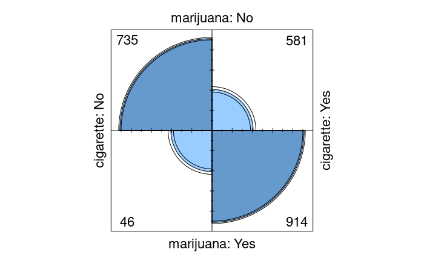

```r
obs.mc.xtabs <- margin.table(obs.xtabs, margin=c(1,2))

fourfoldplot(obs.mc.xtabs)
```

Note that:  
* The area of each shaded quadrant shows the observed counts.  
* Circular arcs show the limits of confidence interval for the odds ratio.

### Tables 2 x 2 x K

Fourfold Plots can be also used for 2 x 2 x K contigancy tables

> - Draw a Fourfold Plot for the contigency table of marijuana cigarette, and alcohol by controlling on the alcohol levels.
> - inspect the plots

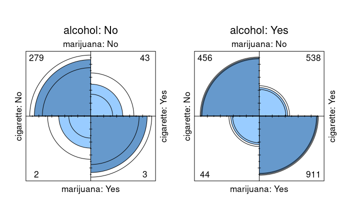

```r
obs.xtabs <- xtabs(count ~ marijuana+cigarette+alcohol, data=obs.frame)

fourfoldplot(obs.xtabs,
             mfrow = c(1,2)
             )
```

## Mosaic plot

Mosaic plot display graphically the cells of a contingency table as rectangular areas of size proportional to the corresponding observed frequencies.

When the classification variables are independent the areas tend to be perfectly aligned in rows and columns.

The greater the deviation is, the worse the aforesaid alignment is.

Furthermore, specific locations of the table that deviate from independence the most can be identified and thus the pattern of underlying association can be explained.

The strength of individual cells contribution to divergence from independence as well as the direction of the divergence are reflected in the magnitude and sign of the corresponding independence model’s residuals that can be incorporated in a mosaic plot.

R provides a function to draw this kind of plots by using the function `mosaic' from the package`vcd’

> - Install `vcd’ package and load it

```r
#install.packages('vcd') # uncomment it if you have not installed package vcd
library(vcd)
```

> - Check the command `mosaic' in help by typing`?mosaic’

> For the I x J case: * Draw a Mosaic Plot for the marginal contigency table of marijuana cigarette. * in particular use use mosaic(x,residuals_type=“deviance”,gp=shading_hcl) where x is the contigency table of interest  
> * Interpretet the plots

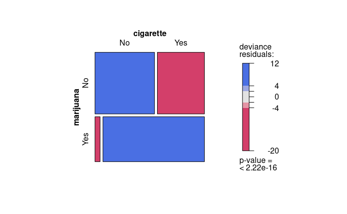

```r
mosaic(obs.mc.xtabs,
       residuals_type="deviance",
       gp=shading_hcl)
```

- I observe a substantial deviation from the Independent association.
- The p-value of the GoF test based on the deviance for independence model is below the colorbar, and smaller than 0.05; hence I reject the hipothesis at sig. level 5%.

> For the I x J x K case: * Draw a Mosaic Plot for the contigency table of marijuana cigarette and alcohol. * Interpretet the plots

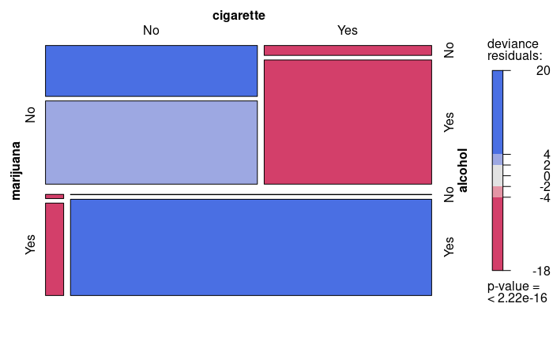

```r
obs.xtabs <- xtabs(count ~ marijuana+cigarette+alcohol, data=obs.frame)
mosaic(obs.xtabs,
       residuals_type="deviance",
       gp=shading_hcl)
```

- I observe a substantial deviation from the Independent association.
- The p-value of the GoF test based on the deviance for independence model is below the colorbar, and smaller than 0.05; hence I reject the hypothesis at sig. level 5%.

# The Iterative Proportions Fitting method

The iterative proportional fitting (IPF) algorithm is a simple method for calculating $\mu_{ijk}$ for log-linear models.

The main idea of the procedure is the following:

- Start with $\mu_{ijk...}^{(0)}$ satisfying a model no more complex than the one being fitted. E.g., $\mu_{ijk...}^{(0)}=1.0$ should be ok.
- For $t=1,...$,
  - adjust $\mu_{ijk}^{(t)}$ to match by multiplying each marginal table in the set of minimal sufficient statistics, by appropriate factors
  - escape the loop, when the maximum difference between the sufficient statistics and their fitted values is sufficiently close to zero.

*Illustration:*

Consider $3$-way, $I\times J\times K$ tables, and with classifiers $X$, $Y$,$Z$.

Given the model $(XY,XZ,YZ)$ design a IPF recursion producing estimates for $\mu_{ijk}$’s

Steps:

- Compute the minimal sufficient statistics are $\{n_{ij+}\}$, $\{n_{i+k}\}$, $\{n_{+jk}\}$.
- Assume that the approximated $\mu_{ijk}$’s from the $(t-1)$-th cycle is $\mu_{ijk}^{(t-1)}$.
- Then the $t$-th cycle of the IPF algorithm has the following steps:
  - Set $m_{ijk}^{(0)}=\mu_{ijk}^{(t-1)}$
  - Compute
    $$\begin{align*}
    m_{ijk}^{(1)} & =m_{ijk}^{(0)}\frac{n_{ij+}}{m_{ij+}^{(0)}};\;\forall i,j,k\\
    m_{ijk}^{(2)} & =m_{ijk}^{(1)}\frac{n_{i+k}}{m_{i+k}^{(1)}};\;\forall i,j,k\\
    m_{ijk}^{(3)} & =m_{ijk}^{(2)}\frac{n_{+jk}}{m_{+jk}^{(2)}};\;\forall i,j,k
    \end{align*}$$
  - Set $\mu_{ijk}^{(t)}=m_{ijk}^{(3)}$, $\forall i,j,k$

…and produces $\mu_{ijk}^{(t)}$ as approximation.

### *Example*

We use the Alcohol, Cigarette, and Marijuana data-set

```r
# I will do this for you

## load the data

obs.frame<-data.frame(count=c(911,538,44,456,3,43,2,279),
                      expand.grid(
  marijuana=factor(c("Yes","No"),levels=c("No","Yes")),
  cigarette=factor(c("Yes","No"),levels=c("No","Yes")),
  alcohol=factor(c("Yes","No"),levels=c("No","Yes")))
  )

## orint the obs.frame

obs.frame
```

| count | marijuana | cigarette | alcohol |
| --- | --- | --- | --- |
| 911 | Yes | Yes | Yes |
| 538 | No | Yes | Yes |
| 44 | Yes | No | Yes |
| 456 | No | No | Yes |
| 3 | Yes | Yes | No |
| 43 | No | Yes | No |
| 2 | Yes | No | No |
| 279 | No | No | No |

```r
NA
```

> - Consider the Log-linear model describing a homogeneous association between each pair of variables at each level of the third one; i.e. $[XY,XZ,YZ]$
> - Find the fitted values for $\mu_{i,j,k}$, by using your own code
> - Check your results with R function ‘loglin{stats}’

*Solution*

```r
# Step 1 :  compute and save the minimal statistics

obs.xtab <- xtabs(obs.frame)
n_xy <- margin.table(obs.xtab,c(1,2))
n_xz <- margin.table(obs.xtab,c(1,3))
n_yz <- margin.table(obs.xtab,c(2,3))

# Step 2: Create a seed for the fitted mu's

# seed the mu_opt
mu_opt <- obs.xtab
for(i in 1:2)
  for(j in 1:2)
    for(k in 1:2)
      mu_opt[i,j,k] = 1.0

# Step 3: Perform the loop to approximate the mu's

for (t in 1: 100) {

  mu_xy <- margin.table(mu_opt,c(1,2))
for(i in 1:2)
  for(j in 1:2)
    for(k in 1:2)
      mu_opt[i,j,k] <- mu_opt[i,j,k]*n_xy[i,j]/mu_xy[i,j]

  mu_xz <- margin.table(mu_opt,c(1,3))

for(i in 1:2)
  for(j in 1:2)
    for(k in 1:2)
      mu_opt[i,j,k] <- mu_opt[i,j,k]*n_xz[i,k]/mu_xz[i,k]

  mu_yz <- margin.table(mu_opt,c(2,3))
for(i in 1:2)
  for(j in 1:2)
    for(k in 1:2)
      mu_opt[i,j,k] <- mu_opt[i,j,k]*n_yz[j,k]/mu_yz[j,k]
}

mu_opt
```

```
, , alcohol = No

         cigarette
marijuana        No       Yes
      No  279.61683  42.38317
      Yes   1.38317   3.61683

, , alcohol = Yes

         cigarette
marijuana        No       Yes
      No  455.38317 538.61683
      Yes  44.61683 910.38317
```

```r
# CHECK WITH COMMAND loglin
obs.xtab <- xtabs(obs.frame)
loglin(obs.xtab,
         list(
           c(1,2),
           c(1,3),
           c(2,3)
           ),
       fit = TRUE)$fit
```

```
4 iterations: deviation 0.09033715
, , alcohol = No

         cigarette
marijuana         No        Yes
      No  279.616949  42.384216
      Yes   1.383051   3.615784

, , alcohol = Yes

         cigarette
marijuana         No        Yes
      No  455.375087 538.626718
      Yes  44.624913 910.373282
```

> Present the fitted $\mu$’s as a data frame

```r
as.data.frame(mu_opt)
```

| marijuana | cigarette | alcohol | Freq |
| --- | --- | --- | --- |
| No | No | No | 279.61683 |
| Yes | No | No | 1.38317 |
| No | Yes | No | 42.38317 |
| Yes | Yes | No | 3.61683 |
| No | No | Yes | 455.38317 |
| Yes | No | Yes | 44.61683 |
| No | Yes | Yes | 538.61683 |
| Yes | Yes | Yes | 910.38317 |

> You can double check your result with the output of the R package

```r
obs.xtab <- xtabs(obs.frame)
library(MASS)
fitAC.AM.CM<-loglm( count~alcohol*cigarette+ alcohol*marijuana +cigarette*marijuana,
              data=obs.xtab,
              param=T,
              fit=T)
fit.array<- fitted(fitAC.AM.CM)
fit.array
```

```
, , alcohol = No

         cigarette
marijuana        No       Yes
      No  279.61440 42.383882
      Yes   1.38316  3.616919

, , alcohol = Yes

         cigarette
marijuana        No      Yes
      No  455.38560 538.6161
      Yes  44.61684 910.3831
```

```r
as.data.frame(fit.array)
```

|  | No.No | Yes.No | No.Yes | Yes.Yes |
| --- | --- | --- | --- | --- |
| No | 279.61440 | 42.383882 | 455.38560 | 538.6161 |
| Yes | 1.38316 | 3.616919 | 44.61684 | 910.3831 |

### *Example*

> - Consider the Log-linear model describing mutual independence; i.e. $[X, Y,Z]$
> 1. Write your own code to compute the fitted values for $\mu_{i,j,k}$
> 2. Check your ewsults with the R command ‘loglin{stats}’

*Solution*

```r
# Step 1 :  compute and save the minimal statistics

obs.xtab <- xtabs(obs.frame)
n_x <- margin.table(obs.xtab,c(1))
n_y <- margin.table(obs.xtab,c(2))
n_z <- margin.table(obs.xtab,c(3))

# Step 2: Create a seed for the fitted mu's

# seed the mu_opt
mu_opt <- obs.xtab
for(i in 1:2)
  for(j in 1:2)
    for(k in 1:2)
      mu_opt[i,j,k] = 1.0

# Step 3: Perform the loop to approximate the mu's

for (t in 1: 100) {

  mu_x <- margin.table(mu_opt,c(1))
  for(i in 1:2)
    for(j in 1:2)
      for(k in 1:2)
      mu_opt[i,j,k] <- mu_opt[i,j,k]*n_x[i]/mu_x[i]

  mu_y <- margin.table(mu_opt,c(2))
  for(i in 1:2)
    for(j in 1:2)
      for(k in 1:2)
      mu_opt[i,j,k] <- mu_opt[i,j,k]*n_y[j]/mu_y[j]

  mu_z <- margin.table(mu_opt,c(3))
  for(i in 1:2)
    for(j in 1:2)
      for(k in 1:2)
      mu_opt[i,j,k] <- mu_opt[i,j,k]*n_z[k]/mu_z[k]
}


mu_opt
```

```
, , alcohol = No

         cigarette
marijuana        No       Yes
      No   64.87990 124.19392
      Yes  47.32880  90.59739

, , alcohol = Yes

         cigarette
marijuana        No       Yes
      No  386.70007 740.22612
      Yes 282.09123 539.98258
```

```r
# CHECK WITH COMMAND loglin
obs.xtab <- xtabs(obs.frame)
loglin(obs.xtab,
         list(
           c(1),
           c(2),
           c(3)
           ),
       fit = TRUE)$fit
```

```
2 iterations: deviation 0
, , alcohol = No

         cigarette
marijuana        No       Yes
      No   64.87990 124.19392
      Yes  47.32880  90.59739

, , alcohol = Yes

         cigarette
marijuana        No       Yes
      No  386.70007 740.22612
      Yes 282.09123 539.98258
```

*Example (Homework)*

```r
# load dataset
obs.frame.accident<-data.frame(
  count=c(7287,11587,3246,6134,10381,10969,6123, 6693,996, 759, 973, 757, 812, 380, 1084, 513) ,
  expand.grid(
    belt=c("No","Yes"),
    location=c("Urban","Rural"),
    gender=c("Female","Male"),
    injury=c("No","Yes"))
)
#print dataset
obs.frame.accident
```

| count | belt | location | gender | injury |
| --- | --- | --- | --- | --- |
| 7287 | No | Urban | Female | No |
| 11587 | Yes | Urban | Female | No |
| 3246 | No | Rural | Female | No |
| 6134 | Yes | Rural | Female | No |
| 10381 | No | Urban | Male | No |
| 10969 | Yes | Urban | Male | No |
| 6123 | No | Rural | Male | No |
| 6693 | Yes | Rural | Male | No |
| 996 | No | Urban | Female | Yes |
| 759 | Yes | Urban | Female | Yes |

[output cut: 6 more lines]

> Consider the Homogeneity association model $(GZ,GS,GI,ZS,ZI,SI)$,  
> 1. Write your own code to compute the fitted values for $\mu_{i,j,k,c}$  
> 2. Check your ewsults with the R command ‘loglin{stats}’

*Solution*

```r
# Step 1 :  compute and save the minimal statistics

obs.frame <- obs.frame.accident

obs.xtab <- xtabs(obs.frame)
n_ZG <- margin.table(obs.xtab,c(2,3))
n_SG <- margin.table(obs.xtab,c(1,3))
n_GI <- margin.table(obs.xtab,c(3,4))
n_SZ <- margin.table(obs.xtab,c(1,2))
n_ZI <- margin.table(obs.xtab,c(2,4))
n_SI <- margin.table(obs.xtab,c(1,4))


# Step 2: Create a seed for the fitted mu's

# seed the mu_opt
mu_opt <- obs.xtab
for(s in 1:2)
  for(z in 1:2)
    for(g in 1:2)
        for(i in 1:2)
          mu_opt[s,z,g,i] = 1.0

# Step 3: Perform the loop to approximate the mu's

for (t in 1: 100) {

  mu_ZG <- margin.table(mu_opt,c(2,3))
  for(s in 1:2)
    for(z in 1:2)
      for(g in 1:2)
        for(i in 1:2)
          mu_opt[s,z,g,i] <- mu_opt[s,z,g,i]*n_ZG[z,g]/mu_ZG[z,g]

  mu_SG <- margin.table(mu_opt,c(1,3))
  for(s in 1:2)
    for(z in 1:2)
      for(g in 1:2)
        for(i in 1:2)
          mu_opt[s,z,g,i] <- mu_opt[s,z,g,i]*n_SG[s,g]/mu_SG[s,g]

  mu_GI <- margin.table(mu_opt,c(3,4))
  for(s in 1:2)
    for(z in 1:2)
      for(g in 1:2)
        for(i in 1:2)
          mu_opt[s,z,g,i] <- mu_opt[s,z,g,i]*n_GI[g,i]/mu_GI[g,i]

  mu_SZ <- margin.table(mu_opt,c(1,2))
  for(s in 1:2)
    for(z in 1:2)
      for(g in 1:2)
        for(i in 1:2)
          mu_opt[s,z,g,i] <- mu_opt[s,z,g,i]*n_SZ[s,z]/mu_SZ[s,z]

  mu_ZI <- margin.table(mu_opt,c(2,4))
  for(s in 1:2)
    for(z in 1:2)
      for(g in 1:2)
        for(i in 1:2)
          mu_opt[s,z,g,i] <- mu_opt[s,z,g,i]*n_ZI[z,i]/mu_ZI[z,i]

  mu_SI <- margin.table(mu_opt,c(1,4))
  for(s in 1:2)
    for(z in 1:2)
      for(g in 1:2)
        for(i in 1:2)
          mu_opt[s,z,g,i] <- mu_opt[s,z,g,i]*n_SI[s,i]/mu_SI[s,i]
}

mu_opt
```

```
, , gender = Female, injury = No

     location
belt       Urban      Rural
  No   7166.3688  3353.8294
  Yes 11748.3087  5985.4930

, , gender = Male, injury = No

     location
belt       Urban      Rural
  No  10471.4955  6045.3062
  Yes 10837.8269  6811.3714

, , gender = Female, injury = Yes

     location
belt       Urban      Rural
  No    993.0169   988.7848
  Yes   721.3055   781.8927

, , gender = Male, injury = Yes

     location
belt       Urban      Rural
  No    845.1187  1038.0796
  Yes   387.5588   518.2429
```

```r
# CHECK WITH COMMAND loglin
obs.frame <- obs.frame.accident
obs.xtab <- xtabs(obs.frame)
loglin(obs.xtab,
         list(
           c(1,2),
           c(1,3),
           c(1,4),
           c(2,3),
           c(2,4),
           c(3,4)
           ),
       fit = TRUE)$fit
```

```
6 iterations: deviation 0.03486629
, , gender = Female, injury = No

     location
belt       Urban      Rural
  No   7166.3680  3353.8313
  Yes 11748.3089  5985.4919

, , gender = Male, injury = No

     location
belt       Urban      Rural
  No  10471.4936  6045.3073
  Yes 10837.8295  6811.3696

, , gender = Female, injury = Yes

     location
belt       Urban      Rural
  No    993.0167   988.7850
  Yes   721.3057   781.8926

, , gender = Male, injury = Yes

     location
belt       Urban      Rural
  No    845.1186  1038.0795
  Yes   387.5591   518.2428
```

> Consider the 3 way interaction model $(GLI,GSI,LSI,GLS)$.  
> 1. Write your own code to compute the fitted values for $\mu_{i,j,k,c}$  
> 2. Check your ewsults with the R command ‘loglin{stats}’

*Solution*

```r
# Step 1 :  compute and save the minimal statistics

obs.frame <- obs.frame.accident

obs.xtab <- xtabs(obs.frame)
n_ZGI <- margin.table(obs.xtab,c(2,3,4))
n_SGI <- margin.table(obs.xtab,c(1,3,4))
n_SZI <- margin.table(obs.xtab,c(1,2,4))
n_SZG <- margin.table(obs.xtab,c(1,2,3))


# Step 2: Create a seed for the fitted mu's

# seed the mu_opt
mu_opt <- obs.xtab
for(s in 1:2)
  for(z in 1:2)
    for(g in 1:2)
        for(i in 1:2)
          mu_opt[s,z,g,i] = 1.0

# Step 3: Perform the loop to approximate the mu's

for (t in 1: 100) {

  mu_ZGI <- margin.table(mu_opt,c(2,3,4))
for(s in 1:2)
  for(z in 1:2)
    for(g in 1:2)
        for(i in 1:2)
        mu_opt[s,z,g,i] <- mu_opt[s,z,g,i]*n_ZGI[z,g,i]/mu_ZGI[z,g,i]

  mu_SGI <- margin.table(mu_opt,c(1,3,4))
for(s in 1:2)
  for(z in 1:2)
    for(g in 1:2)
        for(i in 1:2)
        mu_opt[s,z,g,i] <- mu_opt[s,z,g,i]*n_SGI[s,g,i]/mu_SGI[s,g,i]

  mu_SZI <- margin.table(mu_opt,c(1,2,4))
for(s in 1:2)
  for(z in 1:2)
    for(g in 1:2)
        for(i in 1:2)
        mu_opt[s,z,g,i] <- mu_opt[s,z,g,i]*n_SZI[s,z,i]/mu_SZI[s,z,i]

  mu_SZG <- margin.table(mu_opt,c(1,2,3))
for(s in 1:2)
  for(z in 1:2)
    for(g in 1:2)
        for(i in 1:2)
        mu_opt[s,z,g,i] <- mu_opt[s,z,g,i]*n_SZG[s,z,g]/mu_SZG[s,z,g]
}

mu_opt
```

```
, , gender = Female, injury = No

     location
belt      Urban     Rural
  No   7276.738  3256.262
  Yes 11597.262  6123.738

, , gender = Male, injury = No

     location
belt      Urban     Rural
  No  10391.262  6112.738
  Yes 10958.738  6703.262

, , gender = Female, injury = Yes

     location
belt      Urban     Rural
  No   1006.262   962.738
  Yes   748.738   767.262

, , gender = Male, injury = Yes

     location
belt      Urban     Rural
  No    801.738  1094.262
  Yes   390.262   502.738
```

```r
# CHECK WITH COMMAND loglin
obs.frame <- obs.frame.accident
obs.xtab <- xtabs(obs.frame)
loglin(obs.xtab,
         list(
           c(2,3,4),
           c(1,3,4),
           c(1,2,4),
           c(1,2,3)
           ),
       fit = TRUE)$fit
```

[output not shown]

> Consider the independent model $(G, S, L, I)$
> 1. compute the fitted values for $\mu_{i,j,k,c}$, by using your own code
> 2. check your resutls with ‘loglin{stats}’

*Solution*

```r
# Step 1 :  compute and save the minimal statistics

obs.frame <- obs.frame.accident

obs.xtab <- xtabs(obs.frame)
n_S <- margin.table(obs.xtab,c(1))
n_Z <- margin.table(obs.xtab,c(2))
n_G <- margin.table(obs.xtab,c(3))
n_I <- margin.table(obs.xtab,c(4))


# Step 2: Create a seed for the fitted mu's

# seed the mu_opt
mu_opt <- obs.xtab
for(s in 1:2)
  for(z in 1:2)
    for(g in 1:2)
        for(i in 1:2)
          mu_opt[s,z,g,i] = 1.0

# Step 3: Perform the loop to approximate the mu's

for (t in 1: 100) {

  mu_S <- margin.table(mu_opt,c(1))
for(s in 1:2)
  for(z in 1:2)
    for(g in 1:2)
        for(i in 1:2)
        mu_opt[s,z,g,i] <- mu_opt[s,z,g,i]*n_S[s]/mu_S[s]

  mu_Z <- margin.table(mu_opt,c(2))
for(s in 1:2)
  for(z in 1:2)
    for(g in 1:2)
        for(i in 1:2)
        mu_opt[s,z,g,i] <- mu_opt[s,z,g,i]*n_Z[z]/mu_Z[z]

  mu_G <- margin.table(mu_opt,c(3))
for(s in 1:2)
  for(z in 1:2)
    for(g in 1:2)
        for(i in 1:2)
        mu_opt[s,z,g,i] <- mu_opt[s,z,g,i]*n_G[g]/mu_G[g]

  mu_I <- margin.table(mu_opt,c(4))
for(s in 1:2)
  for(z in 1:2)
    for(g in 1:2)
        for(i in 1:2)
        mu_opt[s,z,g,i] <- mu_opt[s,z,g,i]*n_I[i]/mu_I[i]

}


mu_opt
```

```
, , gender = Female, injury = No

     location
belt       Urban      Rural
  No   8153.4100  4820.3536
  Yes  9971.3181  5895.1137

, , gender = Male, injury = No

     location
belt       Urban      Rural
  No   9493.3447  5612.5324
  Yes 11610.0085  6863.9190

, , gender = Female, injury = Yes

     location
belt       Urban      Rural
  No    819.5209   484.5065
  Yes  1002.2437   592.5335

, , gender = Male, injury = Yes

     location
belt       Urban      Rural
  No    954.2013   564.1305
  Yes  1166.9528   689.9107
```

```r
# CHECK WITH COMMAND loglin
obs.frame <- obs.frame.accident
obs.xtab <- xtabs(obs.frame)
loglin(obs.xtab,
         list(
           c(1),
           c(2),
           c(3),
           c(4)
           ),
       fit = TRUE)$fit
```

```
2 iterations: deviation 7.275958e-12
, , gender = Female, injury = No

     location
belt       Urban      Rural
  No   8153.4100  4820.3536
  Yes  9971.3181  5895.1137

, , gender = Male, injury = No

     location
belt       Urban      Rural
  No   9493.3447  5612.5324
  Yes 11610.0085  6863.9190

, , gender = Female, injury = Yes

     location
belt       Urban      Rural
  No    819.5209   484.5065
  Yes  1002.2437   592.5335

, , gender = Male, injury = Yes

     location
belt       Urban      Rural
  No    954.2013   564.1305
  Yes  1166.9528   689.9107
```

# Newton Method

Newton’s method is a general purpose procedure to compute numerically the solution of a system of non-linear equations given that a number of assumptions are satisfied.

*In general.*

- Let function $f:\mathbb{R}^{n}\rightarrow\mathbb{R}^{n}$.
- Assume you need to find the solution $x^{*}$ of the equation

$$\begin{equation}
f(x^{*})=0\label{eq:asfdgadf}
\end{equation}$$

- Newtons’s method for solving the system () is the recursion

$$\begin{equation}
x^{(t+1)}=x^{(t)}-[\nabla_{x}f(x^{(t)})]^{-1}f(x^{(t)})\label{eq:dfghsdha}
\end{equation}$$

for $t\in\mathbb{N}$ and for a pre-specified seed value $x^{(0)}\in\mathbb{R}^{n}$.

- In theory, Newton’s method converges to the solution quadratically; i.e.
  $$\lim_{t\rightarrow\infty}\frac{|x^{(t+1)}-x^{*}|_{\infty}}{|x^{(t)}-x^{*}|_{\infty}^{2}}=0$$
  under regularity conditions discussed in (Numerical analysis / R. L. Burden, J. D. Faires.)
- In practice, we run Newton’s recursion several times starting from a different seed each time.

*An intuitive explanation why it works*

- From the Taylor expansion, and assuming that $\nabla_{x}^{2}f(x)$ is continuous, I get
  $$f(x_{t+1})=f(x_{t})+\nabla_{x}f(x_{t})(x_{t+1}-x_{t})+O(|x_{t+1}-x_{t}|^{2})$$
  and by ignoring the error term and rearranging the quantities I get
  $$x_{t+1}\sim x_{t}+\nabla_{x}f(x_{t})(f(x_{t+1})-f(x_{t}))$$
- If $x_{t+1}$ is the solution, or close to that, then $f(x_{t+1})=0$, and hence
  $$x_{t+1}\sim x_{t}-\nabla_{x}f(x_{t})f(x_{t})$$
- Now, we see that the gradient of $f$ times the values of $f$ at $x_{t}$ leads the sequence towards locations where $f$ is zero.
- So, eventually, it may work …

*Pseudo-algorithm of Newton’s method:*

`Aim` Approximate the solution of $f(x)=0$

`Input` number of equations $n$; seed $x^{(0)}=(x_{1}^{(0)},...,x_{n}^{(0)})\in\mathbb{R}^{n}$; tolerance $\tau$ ; maximum number of iterations $T$

`Output:` Approximate solution $x^{*}\in\mathbb{R}^{n}$; trace of $x^{(t)}$; trace of relative error $\tau^{(t)}=|x^{(t)}-x^{(t-1)}|_{\infty}$; number of iterations performed $t$

1. Set $x_{\text{opt}}=x^{(0)}$
2. Set $t=1$
3. While ($t\le T$) do:
   1. Compute $n\times1$ vector $F\in\mathbb{R}^{n}$ whose $i$-th element is $F_{i}=f(x_{\text{opt},i})$
   2. Compute $n\times n$ vector $J\in\mathbb{R}^{n\times n}$ whose $(i,j)$-th element is $J_{i,j}=\frac{\text{d}}{\text{d}x_{j}}f_{i}(x_{\text{opt}})$ for $(i,j)\in\{1,...,n\}^{2}$
   3. Solve the $n\times n$ linear system $Jy=-F$ and compute $y\in\mathbb{R}^{n}$
   4. Update $x_{\text{opt}}=x_{\text{opt}}+y$
   5. Compute $\epsilon^{*}= |y|_{\infty}$
   6. If $\epsilon^{*}<\tau$, then escape from the loop
   7. Increase the time step $t=t+1$
4. Set $x^{*}=x_{\text{opt}}$
5. Return as output: Return as output: $x^{*}$, $t^{*}$, and $\epsilon^{*}$.

### *Example*

Solve the system of non-linear equations
$$\begin{cases}
\cos(x_{2}x_{3})+\frac{1}{2} & =3x_{1}\\
81(x_{2}+0.1)^{2} & =x_{1}^{2}+(x_{3}+0.1)^{2}+\sin(x_{3})+1.06\\
-\frac{10\pi-3}{3} & =\exp(-x_{1}x_{2})+20x_{3}
\end{cases}$$

*Solution*

This is equivalent to solving the system $f(x_{1},x_{2},x_{3})=0$ where
$$f(x)=\begin{bmatrix}3x_{1}-\cos(x_{2}x_{3})-\frac{1}{2}\\
x_{1}^{2}-81(x_{2}+0.1)^{2}+\sin(x_{3})+1.06\\
\exp(-x_{1}x_{2})+20x_{3}+\frac{10\pi-3}{3}
\end{bmatrix}$$
with Jacobian
$$\nabla_{x}f(x)=\begin{bmatrix}3 & x_{3}\sin(x_{2}x_{3}) & x_{2}\sin(x_{2}x_{3})\\
2x_{1} & -162(x_{2}+0.1) & \cos(x_{3})\\
-x_{2}\exp(-x_{1}x_{2}) & -x_{1}\exp(-x_{1}x_{2}) & 20
\end{bmatrix}$$

I need to supply the Newton’s algorithm with the quantities above, as well as consider a tolerance, e.g. $1e-4$ (meaning $10^{-4}$), seed value e.g., $x^{(0)}=(0.1,0.1,-0.1)^{T}$, etc…

> Create a function for $f(x)$, and called `my.f()`

```r
my.f <- function(x) {
  f1 <- 3*x[1]-cos(x[2]*x[3])-0.5
  f2 <- x[1]*x[1] -81*(x[2]+0.1)*(x[2]+0.1) +sin(x[3]) +1.06
  f3 <- exp(-x[1]*x[2])+20*x[3]+(10*pi-3)/3
  fvec <- matrix(c(f1,f2,f3),nrow=3)
  return(fvec)
  }
```

> Create a function for $\nabla_x f(x)$, and call it `my.Df`

```r
my.Df <- function(x) {
  Df11 <- 3
  Df12 <- x[3]*sin(x[2]*x[3])
  Df13 <- x[2]*sin(x[2]*x[3])
  Df21 <- 2*x[1]
  Df22 <- -162*(x[2]+0.1)
  Df23 <- cos(x[3])
  Df31 <- -x[2]*exp(-x[1]*x[2])
  Df32 <- -x[1]*exp(-x[1]*x[2])
  Df33 <- 20
  fmat <- matrix( c(Df11, Df21, Df31,
                    Df12, Df22, Df32,
                    Df13, Df23, Df33 ),
                  nrow=3, byrow=FALSE)
  return(fmat)
  }
```

> Create a function called `my.newton.method()` which:
> - gets as arguments:
>   - the function $f(x)$,
>   - the gradient $\nabla_x f(x)$,
>   - number of equations $n$;
>   - seed $x^{(0)}=(x_{1}^{(0)},...,x_{n}^{(0)})\in\mathbb{R}^{n}$;
>   - tolerance $\tau$ ;
>   - maximum number of iterations $T$, etc…
> - returns:
>   - approximate solution $x^{*}\in\mathbb{R}^{n}$;
>   - the last relative error $\tau^{*}$;
>   - number of iterations performed $t^{*}$ , etc…
> - use commands
>   - `solve()` : to solve the system $Ax=b$
>   - `while () {...}`: to perform the loop
>   - `break`: to escape from the loop

```r
my.newton.method <- function(my.f, my.Df, x0, tol, Tmax) {

  xopt = x0

  t = 1

  while (t <= Tmax) {

    xnow = xopt

    F = my.f( xnow )

    J = my.Df( xnow )

    y = solve(J, -F )

    xnew = xnow + y

    xopt = xnew

    err = max(abs(y))

    if ( err <= tol) break

    t = t +1

  }

  return(list(xopt=xopt, Tmax=t, err=err))
}
```

> Solve the equation by using the function the you created

```r
#Try me ...

x0  = c(0.1,0.1,-0.1)
tol = 0.00001
Tmax = 200

obj <- my.newton.method(my.f, my.Df, x0, tol, Tmax)

obj$xopt
```

```
              [,1]
[1,]  5.000000e-01
[2,]  4.005740e-18
[3,] -5.235988e-01
```

```r
obj$Tmax
```

```
[1] 5
```

```r
obj$err
```

```
[1] 7.757857e-10
```

## Newton method for the Log linear model

- I wish to solve non-linear equation $X^{T}n=X^{T}\hat{\mu}(\beta)$ where matrix $X$ is the design matrix given the non-identifiability constrints, e.g., for the model $(XY,XZ,YZ)$.
- Equivalently, I want to find $\hat{\beta}$ for $f(\hat{\beta})=0$ , where $f(\hat{\beta})=X^{T}(n-\mu(\hat{\beta}))$
- The Jacobian is
  $$\begin{align*}
  \nabla_{\beta}f(\beta) & =\nabla_{\beta}X^{T}(n-\mu(\beta))\;=\nabla_{\beta}[X^{T}\mu(\beta)]\\
  & =X^{T}\text{diag}(\mu(\beta))X
  \end{align*}$$
  Because the $(j,k)$th element of $\nabla_{\beta}[X^{T}\mu(\beta)]$ is
  $$\begin{align*}
  \left[\nabla_{\beta}[X^{T}\mu(\beta)]\right]_{j,k} & =-\frac{\text{d}}{\text{d}\beta_{k}}\sum_{i}X_{i,j}\exp(\sum_{j}X_{i,j}\beta_{j})\\
  & =-\sum_{i}X_{i,j}\exp(\sum_{j}X_{i,j}\beta_{j})X_{i,k}
  \end{align*}$$
  since $\mu_{i}(\beta)=\exp(\sum_{j}X_{i,j}\beta_{j})$.
- Then the Newton’s recursion () becomes
  $$\beta_{t+1}=\beta_{t}+[X^{T}\text{diag}(\mu(\beta_{t}))X]^{-1}X^{T}(n-\mu(\beta_{t}))$$
- It is proven that $\beta_{t}\rightarrow\hat{\beta}$.

## Example (For Homework)

Consider the data-set, Alcohol, Cigarette, and Marijuana

```r
## load the data

obs.frame<-data.frame(count=c(911,538,44,456,3,43,2,279),
                      expand.grid(
  marijuana=factor(c("Yes","No"),levels=c("No","Yes")),
  cigarette=factor(c("Yes","No"),levels=c("No","Yes")),
  alcohol=factor(c("Yes","No"),levels=c("No","Yes")))
  )

## orint the obs.frame

obs.frame
```

| count | marijuana | cigarette | alcohol |
| --- | --- | --- | --- |
| 911 | Yes | Yes | Yes |
| 538 | No | Yes | Yes |
| 44 | Yes | No | Yes |
| 456 | No | No | Yes |
| 3 | Yes | Yes | No |
| 43 | No | Yes | No |
| 2 | Yes | No | No |
| 279 | No | No | No |

```r
NA
```

> Consider:
> - a Log-linear model describing a homogeneous association between each pair of variables at each level of the third one; i.e. $[AC,AM,CM]$
> - as identifiability constraints the corner points where the reference levels are the last levels; namely, $2$ (yes), $2$ (yes), and $2$ (yes) for marijuana, cigarette, and alcohol.

> Use Newton method in order to compute $\lambda$’s

> Estimate the log linear model coefficients

*Solution*

```r
# This is a homework for further practice.
```

# Save me

Generate the document as a Notebook, PDF, Word, or HTML by choosing the relevant option (from the pop-up menu next to the Preview button). Then save your Markdown code by choosing the relevant option (from the task bar menu).

Save the *.Rmd script, so that you can edit it later.